[OHI Science](http://ohi-science.org) | [Citation policy](http://ohi-science.org/citation-policy/)

# Annual Commercial Fisheries Catch

Compiled on Mon Aug 14 10:02:48 2017 by afflerbach

This script combines spatial catch data from [Watson (2017)](https://www.nature.com/articles/sdata201739) with species & gear specific categories defined in [`watson_gear_matching`](https://github.com/OHI-Science/impact_acceleration/blob/master/stressors/comm_fish/watson_gear_matching.Rmd) to create annual catch rasters for each of the five fishing stressor categories:

- demersal destructive
- demersal non-destructive high bycatch
- demersal non-destructive low bycatch
- pelagic high bycatch
- pelagic low bycatch

## Overview

- Raw catch data is combined with `taxa_gear_types.csv` as defined in `watson_gear_matching.Rmd`
- Data is filtered for every year and catch type, rasterized to half degree cells, and saved as a GeoTIFF

```r
knitr::opts_chunk$set(fig.width = 6, fig.height = 4, fig.path = 'figs/',message = FALSE, warning = FALSE)

library(seaaroundus)
library(raster)
library(readr)
library(dplyr)
library(data.table)
library(parallel)
library(foreach)
library(doParallel)
library(RColorBrewer)

source('~/github/ohiprep/src/R/common.R')

cols = rev(colorRampPalette(brewer.pal(11, 'Spectral'))(255)) # rainbow color scheme
```

# Load Data

Load raw catch data and the dataset matching gear and taxon to the five stressor categories.

```r
watson_data <- list.files(file.path(dir_M,'git-annex/impact_acceleration/stressors/comm_fish/data/catch'),full.names=T,pattern = '.rds')

#dataset created in watson_gear_matching that assigns each species/gear pair a gear type as defined in Halpern et al. (2008)
gear_taxa <- read_csv('taxa_gear_types.csv')%>%
            dplyr::select(-X1)%>%
            rename(Taxonkey = TaxonKey)
```

# Save annual catch data

The raw data comes with 5 years of data in each file. Here we disaggregate the data by year, join it with the `taxa_gear` data, and save the filtered data as a standalone dataset.

```r
#annual_csv is a function that reads in a raw RDS file, finds all years in the data, filters the data for each year, joins the gear_taxa data and saves its as an .rds on the server

registerDoParallel(10) #register cores

foreach(file = watson_data) %dopar% {

data <- readRDS(file)

yrs <- unique(data$Year)

for(i in 1:length(yrs)){
  print(i)

yr = yrs[i]

yr_data <- data%>%
            filter(Year == yr)%>%
            left_join(gear_taxa, by = c('Taxonkey','TaxonName','CommonName', 'Gear', 'GearName'))

write_rds(yr_data,path = paste0(file.path(dir_M),'/git-annex/impact_acceleration/stressors/comm_fish/int/catch_annual_data/catch_data_',yr,'.rds'))

}
}
```

# Map annual catch

## List annual catch files

To use the datasets just created we define a list of all annual catch datasets.

```r
annual_files <- list.files(file.path(dir_M,'git-annex/impact_acceleration/stressors/comm_fish/int/catch_annual_data'),full.names=T)
```

## Get base raster

Using the [searoundus R package](https://github.com/ropensci/seaaroundus), we create a raster with cell values set equal to cell IDs in the data, which are defined in the column `Seq`.

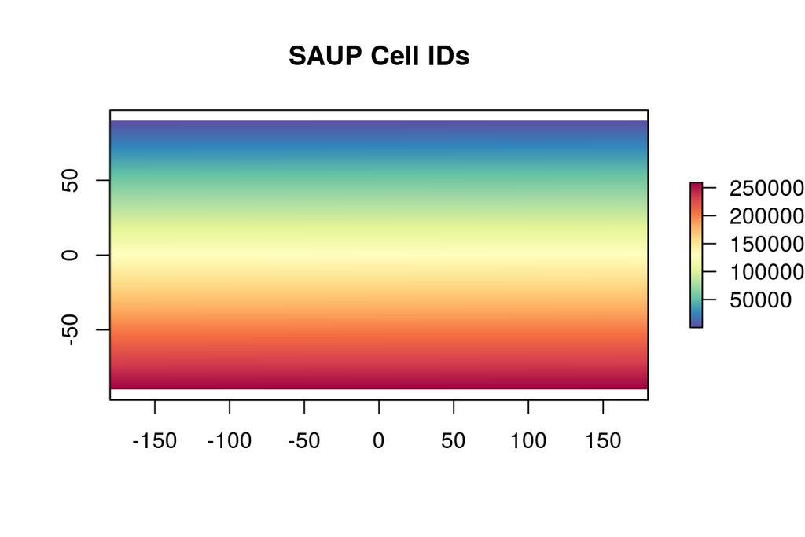

```r
  #get template raster for SAUP data with cell values equal to CellID

   saup_cells <- getcells("POLYGON ((-180 90, 180 90, 180 -90, -180 -90, -180 90))")

   saup_rast <- raster(ncol=720, nrow=360)
   saup_rast[] <- saup_cells

   plot(saup_rast,col=cols,main = "SAUP Cell IDs")
```